# HW Week 7

2023-10-11

## 10.1 Regression Tree model

Let’s begin by getting the data

```r
library(caret)
```

```r
library(rpart)
library(rpart.plot)
library(randomForest)
library(randomForestExplainer)
library(MASS)

myData <- read.table("C:/Users/omkar/OneDrive/Documents/Analytical Tools Folder/uscrime.txt", header = TRUE)

myData2 <- read.table("C:/Users/omkar/OneDrive/Documents/Analytical Tools Folder/germancredit.txt", header = TRUE)

head(myData)
```

|  | M | So | Ed | Po1 | Po2 | LF | M.F | Pop | NW | U1 | U2 | Wealth | Ineq | Prob | Time | Crime |
| --- | --- | --- | --- | --- | --- | --- | --- | --- | --- | --- | --- | --- | --- | --- | --- | --- |
| 1 | 15.1 | 1 | 9.1 | 5.8 | 5.6 | 0.510 | 95.0 | 33 | 30.1 | 0.108 | 4.1 | 3940 | 26.1 | 0.084602 | 26.2011 | 791 |
| 2 | 14.3 | 0 | 11.3 | 10.3 | 9.5 | 0.583 | 101.2 | 13 | 10.2 | 0.096 | 3.6 | 5570 | 19.4 | 0.029599 | 25.2999 | 1635 |
| 3 | 14.2 | 1 | 8.9 | 4.5 | 4.4 | 0.533 | 96.9 | 18 | 21.9 | 0.094 | 3.3 | 3180 | 25.0 | 0.083401 | 24.3006 | 578 |
| 4 | 13.6 | 0 | 12.1 | 14.9 | 14.1 | 0.577 | 99.4 | 157 | 8.0 | 0.102 | 3.9 | 6730 | 16.7 | 0.015801 | 29.9012 | 1969 |
| 5 | 14.1 | 0 | 12.1 | 10.9 | 10.1 | 0.591 | 98.5 | 18 | 3.0 | 0.091 | 2.0 | 5780 | 17.4 | 0.041399 | 21.2998 | 1234 |
| 6 | 12.1 | 0 | 11.0 | 11.8 | 11.5 | 0.547 | 96.4 | 25 | 4.4 | 0.084 | 2.9 | 6890 | 12.6 | 0.034201 | 20.9995 | 682 |

Now let’s begin the process of creating a regression tree model. In week 5, we found that Ed, Po1, Ineq, M, Prob and U2 were good predictors to use, so we will set that as the starting point.

```r
ctrl <- trainControl(method = "cv", number = 5)
custom_cp <- expand.grid(cp = c(0.01, 0.02, 0.03, 0.04, 0.05, 0.06, 0.07, 0.08, 0.09, 0.1, 0.11, 0.12, 0.13))
model <- train(Crime ~ Ed + Po1 + Ineq + M + Prob + U2, data = myData, method = "rpart", tuneGrid = custom_cp, trControl = ctrl)

best_model <- model$finalModel

print(model)
```

```
## CART
##
## 47 samples
##  6 predictor
##
## No pre-processing
## Resampling: Cross-Validated (5 fold)
## Summary of sample sizes: 36, 38, 39, 39, 36
## Resampling results across tuning parameters:
##
##   cp    RMSE      Rsquared   MAE
##   0.01  352.3122  0.2938290  276.1204
##   0.02  352.3122  0.2938290  276.1204
##   0.03  352.3122  0.2938290  276.1204
##   0.04  353.5491  0.2938290  278.2411
##   0.05  353.5491  0.2938290  278.2411
##   0.06  353.5491  0.2938290  278.2411
##   0.07  367.8945  0.2299073  287.5783
##   0.08  367.8945  0.2299073  287.5783
##   0.09  367.8945  0.2299073  287.5783
##   0.10  367.8945  0.2299073  287.5783
##   0.11  367.8945  0.2299073  287.5783
##   0.12  367.8945  0.2299073  287.5783
##   0.13  371.9272  0.2113784  291.7401
##
## RMSE was used to select the optimal model using the smallest value.
## The final value used for the model was cp = 0.03.
```

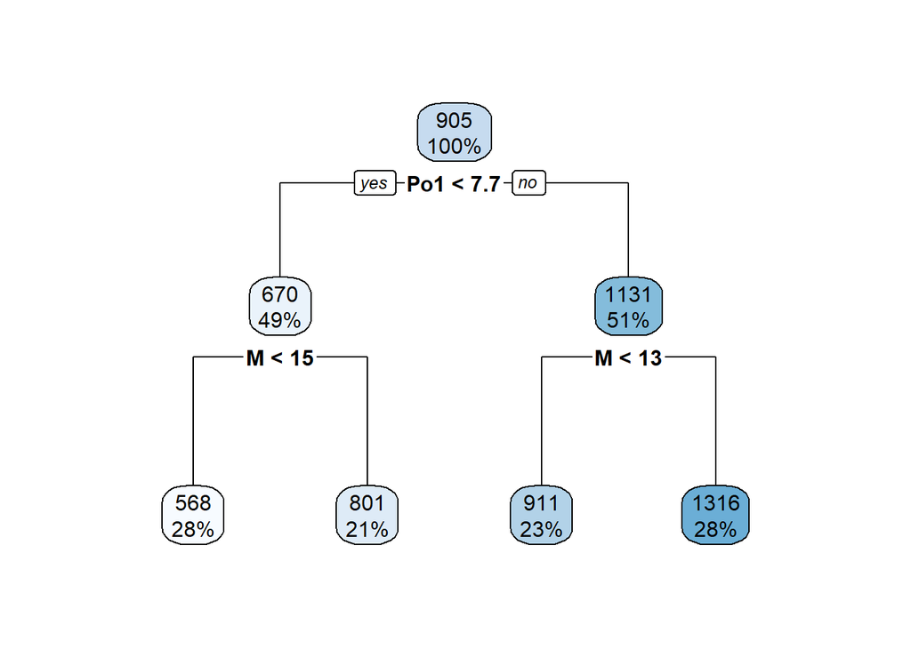

```r
rpart.plot(best_model)
```

Next, we have the random forest model.

```r
rf_model <- randomForest(Crime ~ Ed + Po1 + Ineq + M + Prob + U2, data = myData, ntree = 100, localImp = TRUE)
# Perform cross-validation
cv_results <- train(Crime ~ Ed + Po1 + Ineq + M + Prob + U2, data = myData, method = "rf", trControl = ctrl)
print(cv_results)
```

```
## Random Forest
##
## 47 samples
##  6 predictor
##
## No pre-processing
## Resampling: Cross-Validated (5 fold)
## Summary of sample sizes: 38, 39, 37, 38, 36
## Resampling results across tuning parameters:
##
##   mtry  RMSE      Rsquared   MAE
##   2     293.7142  0.4493552  220.5185
##   4     289.6586  0.4575006  210.8430
##   6     294.0822  0.4346730  211.3630
##
## RMSE was used to select the optimal model using the smallest value.
## The final value used for the model was mtry = 4.
```

Let’s now try to explain the random forest model we have created.

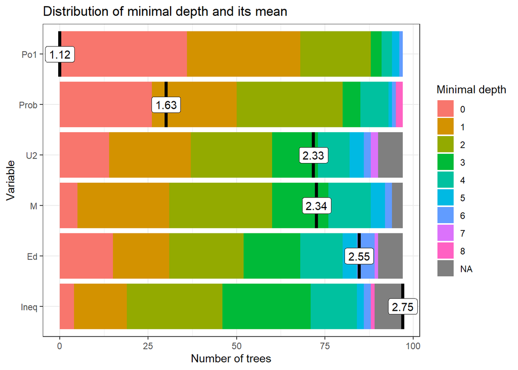

```r
explainer <- min_depth_distribution(rf_model)
plot_min_depth_distribution(explainer)
```

```r
#print(explainer)
#explainer <- explain(rf_model, data = myData, y = myData$Crime)
#var_imp_plot <- plot(explainer)
#print(var_imp_plot)
```

Let’s now see the importance of each variable. From the graph above, it appears that Po1 and Prob are the two most important factors, based on the fact that they have the lowest mean depth compared to other variables. They are also present in the most number of trees as seen in the table below.

```r
importance <- measure_importance(rf_model)
importance
```

| variable | mean_min_depth | no_of_nodes | mse_increase | node_purity_increase | no_of_trees | times_a_root | p_value |
| --- | --- | --- | --- | --- | --- | --- | --- |
| Ed | 2.546907 | 186 | 4981.864 | 680499.9 | 90 | 15 | 0.9999889229 |
| Ineq | 2.754639 | 236 | 5191.879 | 530175.7 | 89 | 4 | 0.7227531396 |
| M | 2.344845 | 240 | 3818.488 | 567069.8 | 94 | 5 | 0.6211596008 |
| Po1 | 1.123711 | 291 | 73177.115 | 2156815.9 | 97 | 36 | 0.0007061523 |
| Prob | 1.628866 | 279 | 27266.153 | 1363603.7 | 97 | 26 | 0.0085605005 |
| U2 | 2.330412 | 232 | 5513.020 | 737402.2 | 90 | 14 | 0.8091692337 |

## 10.2 Qualitative Question

Describe a situation or problem from your job, everyday life, current events, etc., for which a logistic regression model would be appropriate. List some (up to 5) predictors that you might use.

Ans: One situation would be to predict whether or not a subscriber to your service is likely to cancel his membership in the following month. Take for example a streaming service. There are several possible predictors for this:

1. Number of minutes of content viewed in the previous month.
2. The type of subscription membership used - premium 4k vs standard hd, or other categories.
3. The number of months the user has already remained subscribed to the service.
4. Whether or not the user has cancelled his subscription before.
5. (predicted) Age of the user (to get this data you would need to use a different prediction model)

## 10.3 Logistic Regression

Let’s first have a look at the data, convert the right columns to categorical, and then split the data into test and training sets.

```r
head(myData2, 20)
```

|  | A11 | X6 | A34 | A43 | X1169 | A65 | A75 | X4 | A93 | A101 | X4.1 | A121 | X67 | A143 | A152 | X2 | A173 | X1 | A192 | A201 | X1.1 |
| --- | --- | --- | --- | --- | --- | --- | --- | --- | --- | --- | --- | --- | --- | --- | --- | --- | --- | --- | --- | --- | --- |
| 1 | A12 | 48 | A32 | A43 | 5951 | A61 | A73 | 2 | A92 | A101 | 2 | A121 | 22 | A143 | A152 | 1 | A173 | 1 | A191 | A201 | 2 |
| 2 | A14 | 12 | A34 | A46 | 2096 | A61 | A74 | 2 | A93 | A101 | 3 | A121 | 49 | A143 | A152 | 1 | A172 | 2 | A191 | A201 | 1 |
| 3 | A11 | 42 | A32 | A42 | 7882 | A61 | A74 | 2 | A93 | A103 | 4 | A122 | 45 | A143 | A153 | 1 | A173 | 2 | A191 | A201 | 1 |
| 4 | A11 | 24 | A33 | A40 | 4870 | A61 | A73 | 3 | A93 | A101 | 4 | A124 | 53 | A143 | A153 | 2 | A173 | 2 | A191 | A201 | 2 |
| 5 | A14 | 36 | A32 | A46 | 9055 | A65 | A73 | 2 | A93 | A101 | 4 | A124 | 35 | A143 | A153 | 1 | A172 | 2 | A192 | A201 | 1 |
| 6 | A14 | 24 | A32 | A42 | 2835 | A63 | A75 | 3 | A93 | A101 | 4 | A122 | 53 | A143 | A152 | 1 | A173 | 1 | A191 | A201 | 1 |
| 7 | A12 | 36 | A32 | A41 | 6948 | A61 | A73 | 2 | A93 | A101 | 2 | A123 | 35 | A143 | A151 | 1 | A174 | 1 | A192 | A201 | 1 |
| 8 | A14 | 12 | A32 | A43 | 3059 | A64 | A74 | 2 | A91 | A101 | 4 | A121 | 61 | A143 | A152 | 1 | A172 | 1 | A191 | A201 | 1 |
| 9 | A12 | 30 | A34 | A40 | 5234 | A61 | A71 | 4 | A94 | A101 | 2 | A123 | 28 | A143 | A152 | 2 | A174 | 1 | A191 | A201 | 2 |
| 10 | A12 | 12 | A32 | A40 | 1295 | A61 | A72 | 3 | A92 | A101 | 1 | A123 | 25 | A143 | A151 | 1 | A173 | 1 | A191 | A201 | 2 |

[output cut: 10 more lines]

```r
#unique(myData2$X2)
#unique(myData2$X1)
#unique(myData2$X1.1)
cols_to_convert <- c("A11", "A34", "A43", "A65", "A75", "A93", "A101", "A121", "A143", "A152", "A173", "A192", "A201", "X1.1")

for (col in cols_to_convert) {
  myData2[[col]] <- factor(myData2[[col]])
}

train_indices <- createDataPartition(myData2$X1.1, p = 0.7, list = FALSE)

# Create the training dataset
training_data <- myData2[train_indices, ]

# Create the test dataset
test_data <- myData2[-train_indices, ]
```

Now lets fit the logistic regression using the variables provided.

```r
full_model <- glm(X1.1 ~ ., data = training_data, family = binomial(link="logit"))

final_model <- step(full_model, direction = 'both', scope = formula(full_model))
```

```
## Start:  AIC=715.94
## X1.1 ~ A11 + X6 + A34 + A43 + X1169 + A65 + A75 + X4 + A93 +
##     A101 + X4.1 + A121 + X67 + A143 + A152 + X2 + A173 + X1 +
##     A192 + A201
##
##         Df Deviance    AIC
## - A121   3   619.06 711.06
## - A75    4   622.74 712.74
## - A173   3   620.76 712.76
## - X4.1   1   617.94 713.94
## - A143   2   620.44 714.44
## - A101   2   620.49 714.49
## - A93    3   622.51 714.51
## - A201   1   618.75 714.75
## - X2     1   618.88 714.88
## - X1     1   618.91 714.91
## - A152   2   620.98 714.98
## <none>       617.94 715.94
## - A192   1   620.04 716.04
## - X67    1   621.03 717.03
## - X1169  1   621.17 717.17
## - A34    4   628.46 718.46
## - X4     1   622.60 718.60
## - A65    4   630.02 720.02
## - X6     1   626.49 722.49
## - A43    9   654.04 734.04
## - A11    3   674.33 766.33
##
## Step:  AIC=711.06
## X1.1 ~ A11 + X6 + A34 + A43 + X1169 + A65 + A75 + X4 + A93 +
##     A101 + X4.1 + X67 + A143 + A152 + X2 + A173 + X1 + A192 +
##     A201
##
##         Df Deviance    AIC
## - A75    4   623.97 707.97
## - A173   3   622.05 708.05
## - X4.1   1   619.08 709.08
## - A93    3   623.48 709.48
## - A143   2   621.93 709.93
## - A201   1   619.96 709.96
```

[output cut: 269 more lines]

```
## + A143   2   637.59 697.59
## + A192   1   639.72 697.72
## - A152   2   645.81 697.81
## + A93    3   636.06 698.06
## + A75    4   634.10 698.10
## + X4.1   1   640.16 698.16
## + X1     1   640.17 698.17
## - X67    1   645.26 699.26
## + A173   3   637.76 699.76
## + A121   3   638.48 700.48
## - A65    4   652.80 700.80
## - A34    4   655.21 703.21
## - A43    9   678.00 716.00
## - X6     1   667.87 721.87
## - A11    3   697.70 747.70
```

```r
summary(final_model)
```

```
##
## Call:
## glm(formula = X1.1 ~ A11 + X6 + A34 + A43 + A65 + X4 + A101 +
##     X67 + A152, family = binomial(link = "logit"), data = training_data)
##
## Coefficients:
##               Estimate Std. Error z value Pr(>|z|)
## (Intercept)   1.314904   0.721770   1.822  0.06849 .
## A11A12       -0.323523   0.247968  -1.305  0.19200
## A11A13       -1.083367   0.429665  -2.521  0.01169 *
## A11A14       -1.851646   0.276690  -6.692 2.20e-11 ***
## X6            0.045408   0.008923   5.089 3.60e-07 ***
## A34A31       -0.070099   0.646514  -0.108  0.91366
## A34A32       -0.761082   0.494133  -1.540  0.12350
## A34A33       -0.664572   0.543431  -1.223  0.22136
## A34A34       -1.413311   0.518139  -2.728  0.00638 **
## A43A41       -1.802351   0.451030  -3.996 6.44e-05 ***
## A43A410      -0.865241   0.873344  -0.991  0.32182
## A43A42       -0.689636   0.295330  -2.335  0.01954 *
## A43A43       -0.940258   0.288232  -3.262  0.00111 **
## A43A44       -0.470493   0.860538  -0.547  0.58456
## A43A45       -0.511060   0.621076  -0.823  0.41059
## A43A46        0.863453   0.501108   1.723  0.08487 .
## A43A48      -15.161287 515.024447  -0.029  0.97652
## A43A49       -0.844405   0.385621  -2.190  0.02854 *
## A65A62       -0.322704   0.323090  -0.999  0.31789
## A65A63       -0.459896   0.478100  -0.962  0.33609
## A65A64       -1.294915   0.556419  -2.327  0.01995 *
## A65A65       -0.836078   0.317735  -2.631  0.00850 **
## X4            0.164342   0.092521   1.776  0.07569 .
## A101A102      0.280605   0.469769   0.597  0.55029
## A101A103     -0.914206   0.461709  -1.980  0.04770 *
## X67          -0.022743   0.010300  -2.208  0.02724 *
## A152A152     -0.553781   0.262281  -2.111  0.03474 *
## A152A153     -0.088820   0.409959  -0.217  0.82848
## ---
## Signif. codes:  0 '***' 0.001 '**' 0.01 '*' 0.05 '.' 0.1 ' ' 1
##
## (Dispersion parameter for binomial family taken to be 1)
##
##     Null deviance: 855.21  on 699  degrees of freedom
## Residual deviance: 640.19  on 672  degrees of freedom
## AIC: 696.19
##
## Number of Fisher Scoring iterations: 14
```

For the next question, we will find the correct threshold, if they estimate that incorrectly identifying a bad customer as good, is 5 times worse than incorrectly classifying a good customer as bad. First, we have to create a confusion matrix. So, I iterated over several values of the threshold, and made sure that there were 5 times as many false positives as false positives. This gave me a threshold probability of 0.172, as shown below

```r
predictions <- predict(final_model, newdata = test_data, type = "response")

predicted_labels <- as.factor(ifelse(predictions > 0.172, 2, 1))
confusion_matrix <- confusionMatrix(data = predicted_labels, reference = test_data$X1.1)
print(confusion_matrix)
```

```
## Confusion Matrix and Statistics
##
##           Reference
## Prediction   1   2
##          1 118  16
##          2  91  74
##
##                Accuracy : 0.6421
##                  95% CI : (0.5849, 0.6965)
##     No Information Rate : 0.699
##     P-Value [Acc > NIR] : 0.9853
##
##                   Kappa : 0.3126
##
##  Mcnemar's Test P-Value : 8.438e-13
##
##             Sensitivity : 0.5646
##             Specificity : 0.8222
##          Pos Pred Value : 0.8806
##          Neg Pred Value : 0.4485
##              Prevalence : 0.6990
##          Detection Rate : 0.3946
##    Detection Prevalence : 0.4482
##       Balanced Accuracy : 0.6934
##
##        'Positive' Class : 1
##
```